# Passo a passo do mapeamento genético

Letícia Lara e Marianella Quezada

23-04-2015

Neste arquivo serão apresentados os passos realizados para o mapeamento genético de uma população $F_{2}$ de *Mimulus*. O mapa inicial já foi publicado por Fishman *et al.* (2001) e será utilizado como um direcionamento, quando necessário. Novos marcadores serão incluídos, com a finalidade de melhorar este mapa genético.

### 1º passo

Instalação dos pacotes dplyr, OneMap e ggplot2.

```r
install.packages("onemap") # instalando o pacote
```

```r
library(dplyr)   # para carregar o pacote
library(magrittr)
library(onemap)
```

```r
library(ggplot2)
```

Leitura dos dados de *Mimulus*.

```r
mimulus <- read.mapmaker(file = "mimulus.txt") # leitura de dados

mimulus  #informacion do conjunto de dados
```

Nestes novos dados, serão analisados 418 marcadores em um conjunto de 287 indivíduos da geração $F_{2}$. Dentre esses marcadores, 213 são codominantes e 205 são dominantes (113 + 92).

Uma análise inicial quanto à segregação dos marcadores será realizada, com a finalidade de observar quais marcadores apresentam distorção de segregação. A distorção de segregação é um fenômeno comum em estudos de mapeamento e sua ocorrência varia muito em função do tipo de população, dos marcadores moleculares utilizados e os própios aspectos biológicos da espécie. A utilização de um grande número de indivíduos na população e de genitores contrastantes é recomendada para evitar a ocorrência de distorção de segregação por acaso.

Na literatura há divergências quanto as consequências em manter ou não marcadores com distorção de segregação. Alguns autores acreditam que a distorção de segregação dos marcadores não os exclui de serem potencialmente informativos, enquanto outros não aconselham usá-los para construção de mapas genéticos. Segundo Xu (2008), quando o desvio de segregação não é muito pronunciado, ou quando o marcador está intimamtente ligado ao QTL, a identificação feita pelo marcador não é prejudicada. Desta forma, optou-se por, inicialmente, utilizar todos os marcadores para construção do mapa.

### 2º passo

Análise de segregação mendeliana.

```r
dados <- data.frame(mimulus$geno)
marcadores <- colnames(dados)

dim(dados)
```

```
## [1] 287 418
```

```r
dados[1:10, 1:10]
```

```
##    AA461 AA420 AA404 AA384 AA378 AA371C AA361 AA341 AA311 AA280
## 1      1     1     1     1     1      1     1     1     1     1
## 2      1     1     1     2     1      2     1     1     1     1
## 3      1     1     1     1     1      2     2     1     1     1
## 4      1     1     1     1     2      2     1     2     1     1
## 5      2     2     1     1     1      2     1     1     2     2
## 6      2     1     1     1     2      3     1     2     1     2
## 7      2     1     1     2     2      2     2     1     2     1
## 8      1     2     1     1     1      3     1     2     1     2
## 9      1     1     1     2     2      3     1     1     1     1
## 10     1     1     1     1     1      1     1     1     1     2
```

Analisando os dados, foi observada uma mudança na codificação, com o seguinte padrão:

Marcadores codominantes:

- A : 1
- B : 3
- H : 2
- - : 0

Marcadores dominantes parental 1:

- A : 2
- C : 1
- - : 0

Marcadores dominantes parental 2:

- B : 2
- D : 1
- - : 0

Para cada marcador, será contabilizado o número total de cada fenótipo molecular.

```r
contagem <- NULL
n0 <- NULL; n1 <- NULL; n2 <- NULL; n3 <- NULL
for(i in 1:(ncol(dados))){
  cont <- table(dados[,i])
  n0[i] <- cont[1]
  n1[i] <- cont[2]
  n2[i] <- cont[3]
  n3[i] <- cont[4]
  contagem <- rbind(contagem, cbind(n0[i], n1[i], n2[i], n3[i]))
}

contagem <- data.frame(contagem)
contagem <- cbind(marcadores, contagem)
colnames(contagem) <- c("marcadores", "n0", "n1", "n2", "n3")
head(contagem, 8)
```

```
##   marcadores n0  n1  n2 n3
## 1      AA461 12 184  91 NA
## 2      AA420 12 213  62 NA
## 3      AA404 12 216  59 NA
## 4      AA384 12 192  83 NA
## 5      AA378 12 181  94 NA
## 6     AA371C 12  54 140 81
## 7      AA361 12 222  53 NA
## 8      AA341 12 217  58 NA
```

```r
codominantes <- na.omit(contagem)
dominantes <- contagem [is.na(contagem$n3), ]
```

Considerando que serão realizados múltiplos testes, será aplicada uma correção de Bonferroni, para estabelecer se os marcadores apresentam distorção de segregação ou não. Desta forma, temos:

$\quad \quad \alpha_{c} \approx \dfrac{\alpha^{*}}{m} \approx \dfrac{0.05}{n. marcadores}$

No artigo de referência, não foi considerada esta correção, sendo os níveis $\alpha$ pré-estabelecidos em 0.05 e 0.001. Estes níveis também serão analisados neste trabalho.

```r
dist.co <- codominantes %>%
              mutate(n = n1 + n2 + n3,
                chi.square = (((n1 - n*0.25) ^2) / (n*0.25) +
                             ((n2 - n*0.50) ^2) / (n*0.50)  +
                             ((n3 - n*0.25) ^2) / (n*0.25)),
                p.valor = pchisq (chi.square, df=2, lower.tail=FALSE))

alpha.co <- 0.05 / 213
alpha.co
```

```
## [1] 0.0002347
```

```r
dist.co %>% filter (p.valor < alpha.co) %>%
  dim
```

```
## [1] 48  8
```

```r
dist.do <- dominantes %>%
              select(marcadores:n2) %>%
              mutate(n = n1 + n2,
                 chi.square = ((n1 - n*0.75) ^2) / (n*0.75) +
                              ((n2 - n*0.25) ^2) / (n*0.25),
                 p.valor = pchisq (chi.square, df=1, lower.tail=FALSE))

alpha.do <- 0.05 /205
alpha.do
```

```
## [1] 0.0002439
```

```r
dist.do %>%  filter (p.valor < alpha.do) %>%
  dim
```

```
## [1] 20  7
```

Comparando os diferentes níveis de $\alpha$ e a correção de Bonferroni ($\alpha_{c}$) para estabelecer quais marcadores apresentam distorção de segregação, obtemos:

| Critério | Codominantes | Dominantes | Total |
| --- | --- | --- | --- |
| $\alpha$ = 0.05 | 100 | 76 | 176 |
| $\alpha$ = 0.001 | 58 | 27 | 85 |
| $\alpha_{c}$ = 0.00024 | 48 | 20 | 68 |

```r
p.valor <- c (dist.co$p.valor, dist.do$p.valor)
length(p.valor)
```

```
## [1] 418
```

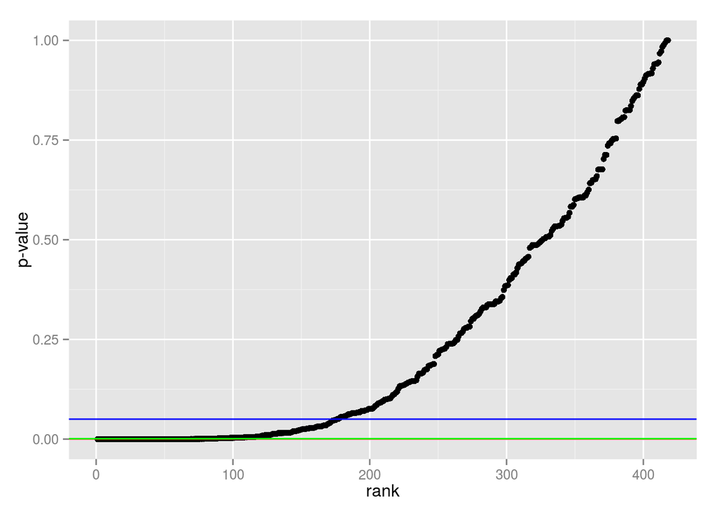

```r
pval <- sort(p.valor)
rank <- c(1:418)

ggplot() +
  geom_point(aes (x = rank, y = pval)) +
  xlab ("rank") +
  ylab ("p-value") +
  geom_hline(yintercept=0.05, colour="blue") +    # linha alpha=0.05
  geom_hline(yintercept=0.00024, colour="red") +  # linha correcao bonferroni
  geom_hline(yintercept=0.001, colour="green")    # linha alpha=0.001
```

A linha azul refere-se ao nível $\alpha$ de significância de 0.05. A linha verde refere-se ao nível $\alpha$ de significância de 0.001. A linha vermelha (colada à verde) refere-se ao nível de significância com correção de Bonferroni ($\alpha$ = 0.00024)

### 3º passo

Estabelecimento da frequência de recombinação entre todos os pares de marcadores.

```r
freqrecomb <- rf.2pts(mimulus, LOD = 3, max.rf = 0.50) # teste de dois pontos
```

### 4º passo

No artigo de Fishman *et al.* (2001), foi utilizado um LOD *score* de $6.0$ e a distância máxima de $37$ cM. Como neste novo mapa estão incluídos mais marcadores, será realizada o cálculo de qual LOD é mais adequado para essa situação.

```r
marcadores <- make.seq(freqrecomb, "all")  # fazendo uma sequência de todos os marcadores

ntestes<- choose(418, 2)
dist <- qchisq(1-(0.05/ntestes),1)
LOD <- 0.2172 * dist
LOD
```

```
## [1] 5.43
```

Inicialmente, foram feitos vários testes utilizando-se diferentes frequências de recombinação máxima e posteriormente optou-se em utilizar um max.rf de 0.4.

```r
grupos <- group(marcadores, LOD=6, max.rf=0.4)  # atribuindo marcadores em GL

grupos          # mostra quais foram os grupos que se formaram
```

```
##   This is an object of class 'group'
##   It was generated from the object "marcadores"
##
##   Criteria used to assign markers to groups:
##     LOD = 6 , Maximum recombination fraction = 0.4
##
##   No. markers:            418
##   No. groups:             10
##   No. linked markers:     411
##   No. unlinked markers:   7
##
##   Printing groups:
##   Group 1 : 82 markers
##     AA461 AA341 AA173C AA137 BA449 BA416 BA387 BA374 BA214 BA196 BA153 BA129 BB216 BB124 CA267 CA174 CA150 CA75 BD371 BD340 BD270 BD251 BD100 CA389C AAT225 AAT267 AAT265 BC542 BC374 BC80 BC526C BC194C CC447 CC320 CC138 CC93 CC61 CC53 AAT333 AP3 MgSTS17 MgSTS16 MgSTS18 MgSTS20 MgSTS19 MgSTS24 MgST…
##
##   Group 2 : 22 markers
##     AA420 BA301 BA172 BA125 CA279 CA228 CB280 BD175 BD99 BC167 BC126 CC132 CC130 CC385C MgSTS316 MgSTS49 MgSTS106 MgSTS56 MgSTS457 MgSTS513 MgSTS589 MgSTS565
##
##   Group 3 : 87 markers
##     AA404 AA361 AA280 AA100 BA497 BA384 BA220 BA75 BB281 BB259 BB190 BB122 BB119 BB102 CA289 CA238 CA220 CA198 CA131 CA96 CB309 CB246 CB187 CB173 CB166 CB162 CB156 BD433 BD429 BD292 BD286 BD263 BD209 BD170 BD68 AA153C CA258C BB103C AAT261 AAT278 AAT374 AAT372 AG19 BC498 BC379 BC334 BC131 BC70 BC5…
##
##   Group 4 : 40 markers
##     AA384 AA166C AA66 BA210 BA113 BB208 CA497 CA415 CA399 CA384 CA297 CA233 CB329 CB257 BD411 BD243 BD239 BD130 BD115 AA346C AA374C BA279C CA183C AAT367 BC512 BC321 BC216 BC192 CC531 CC270 MgSTS132 MgSTS228 MgSTS234 MgSTS455 MgSTS262 MgSTS362 MgSTS492 MgSTS347 MgSTS477 MgSTS542B
##
##   Group 5 : 21 markers
##     AA378 AA268 AA163 BA69 BB210 BB186 CA264 CA226 CB230 BD316C BD173 AA118C AA454C BC506 CC342 CC124 MgSTS40 MgSTS245 MgSTS282A MgSTS255 MgSTS586
##
##   Group 6 : 51 markers
##     AA371C AA311 AA277 AA270 AA158 BA222 BA117 CA283 CA152C CB333 BD179 BD169 BD55 AAT230 AAT300 BC392 BC243 BC125 CC457 CC381 CC262 CC126 CC171C MgSTS21 MgSTS25 MgSTS22 MgSTS28 MgSTS105 MgSTS120 MgSTS58 MgSTS229 MgSTS323 MgSTS508 MgSTS529 MgSTS480 MgSTS426 MgSTS453 MgSTS456 MgSTS430 MgSTS314 MgS…
##
##   Group 7 : 32 markers
##     AA246 BA372 BA314 BA158 BB167 CA305 CA210 CA122 CB272 BD189C AAT217 AAT39 AAT211 AAT296 CYCB AAT242 CC450 CC359 CC338C MgSTS59 MgSTS69 MgSTS31 MgSTS76 MgSTS330 MgSTS381 MgSTS571 MgSTS590 MgSTS537 MgSTS538 MgSTS563 MgSTS504C MgSTS621
##
##   Group 8 : 26 markers
##     AA167 AA95 BA445 BA400 BA311 BB218 BB176 CA261 CA217 CA196 CA167 CB115 BA396C AAT222 BC108 BC83 CC540 CC402 LFY MgSTS468 MgSTS638 MgSTS536 MgSTS558 MgSTS611 MgSTS600 MgSTS470
##
##   Group 9 : 29 markers
##     BA394 BA175 BB182 CA378 CA140 CB216 BD242 BD143 AA296C BA245C AAT233 AAT272 AAT308 AAT364 BC546 BC478 BC388 BC376 BC330 BC266 BC219 CC149 CC114 MgSTS36 MgSTS437 MgSTS113 MgSTS282B MgSTS548 MgSTS438
##
##   Group 10 : 21 markers
##     BA334 BA145 BB198 CA315 CB172 CB126 CB55 CB263C AAT240 BC199 CC150 MgSTS55 MgSTS45 MgSTS11 MgSTS68 MgSTS326 MgSTS419 MgSTS577 MgSTS104 MgSTS622 MgSTS599
##
##   Unlinked markers: 7  markers
##     AA208 BB327 BB279 CA392 BC135 CC371 MgSTS23
```

```r
set.map.fun(type="kosambi") # estabelecendo uma distância para o mapa
```

Com essa análise, foram obtidos 10 grupos de ligação, sendo que sete marcadores ficarão não ligados a nenhum grupo (AA208, BB327, BB279, CA392, BC135, CC371, MgSTS23).

### 5º passo

Os passos seguintes são analisar cada grupo de ligação isoladamente, detectar falsos positivos (usando o gráfico heatmap), verificar o melhor ordenamento dos marcadores dentro de cada grupo.

Dentre os diversos critérios de ordenação disponíveis na literatura, os mais utilizados são: seriação (*seriation* - SER), delineação rápida em cadeia (*Rapid Chain Delineation* - RCD), contagem de recombinação e ordenação (*Recombination Counting and Ordering* - RECORD) e crescimento unidirecional (*Unidirectional Growth* - UG). Para uma visualização inicial do ordenamento dos marcadores no grupo de ligação, foi utilizado o critério RCD.

O algoritmo inicialmente utilizado neste trabalho foi o RDC, o qual considera a matriz de recombinações de todos os pares de marcas, porém não necessita que os marcadores já estejam separados por grupos de ligação. Inicia-se com o par de marcas com menor r e adiciona-se uma a uma as demais marcas com menores r nas extremidades da cadeia. O processo é encerrado quando não restarem mais marcas ou quando as restantes não estiverem significativamente ligadas a nenhuma outra. A principal desvantagem neste método é não assegurar a melhor ordenação. No entanto ele foi utilizado por ser rápido computacionalmente e para se obter uma idéia geral do posicionamento dos marcadores dentro de cada grupo.

No entanto, para o ordenamento final dos marcadores foi utilizado a função **order.seq()**. Esta função utiliza o comando **compare** (comparação de todas as ordens possíveis) para criar um mapa inicial apenas com um conjunto pequeno de marcadores em cada grupo (subset utilizado de 5 marcadores). Seguidamente o restante dos marcadores são posicionados utilizando o comando **try.seq()**.

Este comando **try.seq()** acrescenta $m'$ marcadores sequencialmente em todos os intervalos de uma subordem inicial, testando qual a posição mais provável de cada um deles. A subordem inicial pode ser obtida por busca exaustiva (**compare**), comparando as $m'!/2$ ordens possíveis. Assim, para cada uma dessas subordens é construído um mapa e calculada a verossimilhança por cadeia de Markov oculta. O sub-mapa com maior verossimilhança será considerado o correto. Posteriormente escolhe-se um marcador não mapeado (codominantes antes de dominantes e marcadores com menores níveis de dados perdidos), que poderá se posicionar em qualquer dos intervalos entre os marcadores ou nas extremidades ($m'+1$ posições possíveis). Para cada uma posição o mapa é reconstruído, reestimadas as frações de recombinação e calculada a verossimilhança nova. A ordem que apresentar maior verossimilhança é considerada a ordem correta e o marcador posicionado neste local. Finalmente, os marcadores são posicionados e os que possuem mais de uma posição possível são alocados na melhor posição utilizando a função **make.seq()**, com o comando **forced**.

Uma verificação final da ordem será realizada utilizando-se o algoritmo RIPPLE.

O nome de cada grupo de ligação neste trabalho será estabelecido seguindo a presença dos marcadores nos grupos de ligação do mapa de referência.

**Primeiro grupo maior**

```r
maior1 <- make.seq(grupos, 1)  # trabalhando com o grupo de ligação 1
maior1
```

Neste grupo de ligação, foram agrupados 82 marcadores, sendo 12 marcadores coincidentes com os marcadores do LG1, 12 marcadores coincidentes com os do LG11 e 11 marcadores coincidentes com os do LG14 do mapa de referência. Posteriormente, os marcadores serão ordenados dentro deste grupo de ligação por um critério de ordenação previamente selecionado.

```r
maior1.rcd <- rcd(maior1)        # ordenando pelo rcd
```

```r
rf.graph.table(maior1.rcd)    # ver graficamente a ordenação dos marcadores
```

```r
maior1.ord <- order.seq(input.seq=maior1,
                        n.init = 5,
                        subset.search = "twopt",
                        twopt.alg = "rcd",
                        THRES = 3,
                        draw.try = FALSE,
                        wait = 1,
                        touchdown=TRUE)
maior1.ord                                # mapa com ordenação order

maior1.fin <- make.seq(maior1.ord, "force")
maior1.fin
```

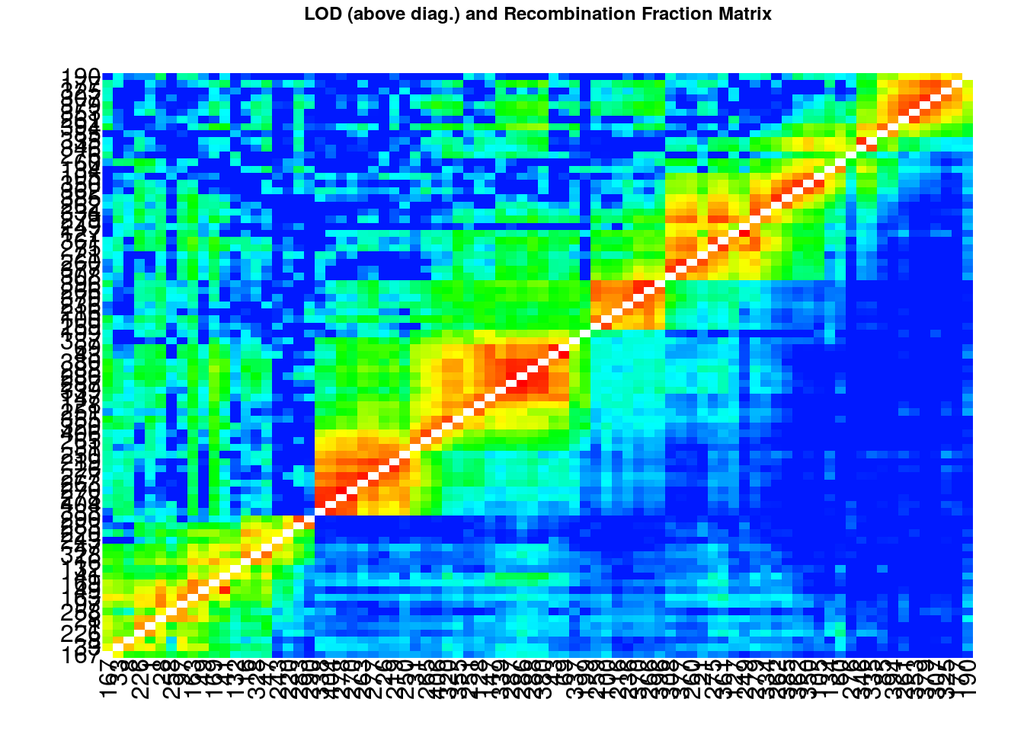

```r
rf.graph.table(maior1.fin, inter=FALSE)
```

O grupo de ligação maior foi subdividido em três grupos de menor tamanho, a partir da visualização do *heatmap*, do estudo da presença de *gaps* no mapa ordenado e da informação prévia dos grupos de ligação no mapa de referẽncia.

Subdividindo o primeiro maior grupo de ligação:

```r
maior1seq1 <- make.seq(freqrecomb, c(167, 33, 8, 226, 1, 28, 258, 97, 163, 49, 169, 41,
                                  132, 16, 328, 47, 243, 220, 283, 290))
maior1seq2 <- make.seq(freqrecomb, c(338, 404, 278, 270, 263, 277, 26, 219, 250, 31, 265,
                                  406, 320, 355, 251, 128, 147, 339, 287, 286, 288, 380,
                                  43, 69, 337, 199))
maior1seq3 <- make.seq(freqrecomb, c(259, 100, 216, 236, 370, 266, 396, 308, 377, 260, 21,
                                  275, 361, 127, 249, 279, 334, 262, 385, 362, 350, 105,
                                  134, 60, 276, 346, 335, 85, 394, 261, 353, 379, 307, 325,
                                  177, 190))
```

**Grupo 1**

Agora trabalhando com a primeira sequência gerada, a qual corresponde ao LG1 do mapa de referência.

```r
LG1.ord <- order.seq(input.seq=maior1seq1,
                        n.init = 5,
                        subset.search = "twopt",
                        twopt.alg = "rcd",
                        THRES = 3,
                        draw.try = FALSE,
                        wait = 1,
                        touchdown=TRUE)
LG1.ord

LG1.new.fin <- make.seq(LG1.ord, "force")  # criando o mapa final
LG1.new.fin      # mapa final
```

Neste grupo de ligação, foram agrupados 20 marcadores, sendo 12 marcadores coincidentes com os marcadores do LG1 do mapa original e 8 novos marcadores.

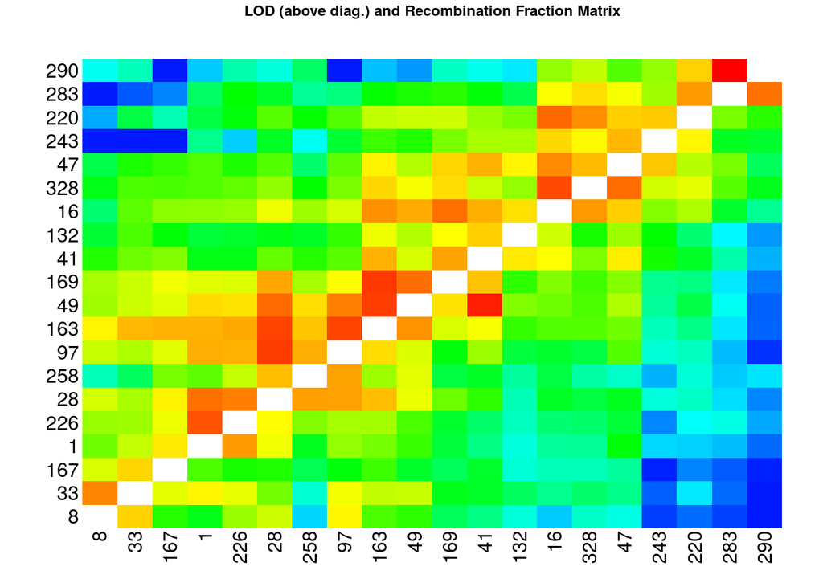

```r
rf.graph.table(LG1.new.fin, inter=FALSE)
```

A ordenação utilizando o comando **order.seq()** foi eficiente observando o gráfico do *heatmap*. A ordenação local foi verificada utilizando a função **ripple.seq()**. Esta ordenação se manteve coincidente com a ordem global.

```r
ripple.seq(LG1.new.fin, ws=5, LOD=3)   # verificando a ordem do mapa final
```

| Grupo 1 | Verossimilhança | Comprimento | N. Marcadores |
| --- | --- | --- | --- |
| Todos os marcadores | -2588.687 | 217.04 | 20 |

**Grupo 11**

Agora trabalhando com a segunda sequência gerada, a qual corresponde ao LG11 do mapa de referência.

```r
LG11.ord <- order.seq(input.seq=maior1seq2,
                        n.init = 5,
                        subset.search = "twopt",
                        twopt.alg = "rcd",
                        THRES = 3,
                        draw.try = FALSE,
                        wait = 1,
                        touchdown=TRUE)
LG11.ord

LG11.new.fin <- make.seq(LG11.ord, "force")
LG11.new.fin
```

Neste grupo de ligação, foram agrupados 26 marcadores, sendo 12 marcadores coincidentes com os marcadores do LG11 do mapa de referência e 14 novos marcadores.

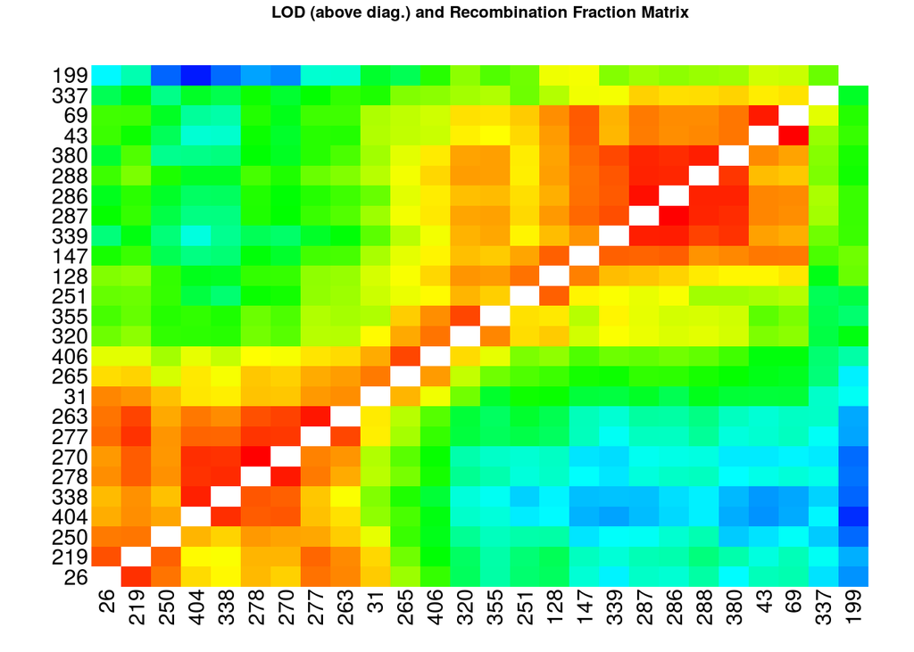

```r
rf.graph.table(LG11.new.fin, inter=FALSE)
```

A ordenação utilizando o comando **order.seq()** foi eficiente observando o gráfico do *heatmap*. A ordenação local foi verificada utilizando a função **ripple.seq()**. Esta ordenação se manteve coincidente com a ordem global.

```r
ripple.seq(LG11.new.fin, ws=5, LOD=3)
```

| Grupo 11 | Verossimilhança | Comprimento | N. Marcadores |
| --- | --- | --- | --- |
| Todos os marcadores | -2516.732 | 168.42 | 26 |

**Grupo 14**

Agora trabalhando com a terceira sequência gerada, a qual corresponde ao LG14 do mapa de referência.

```r
LG14.ord <- order.seq(input.seq=maior1seq3,
                        n.init = 5,
                        subset.search = "twopt",
                        twopt.alg = "rcd",
                        THRES = 3,
                        draw.try = FALSE,
                        wait = 1,
                        touchdown=TRUE)
LG14.ord

LG14.fin <- make.seq(LG14.ord, "force")
LG14.fin

round(diff(cumsum(LG14.fin$seq.rf)), 3)   # Calcula a frequência de recombinação
                                          # entre pares de marcadores
```

Neste grupo de ligação, foram agrupados 36 marcadores, sendo 11 marcadores coincidentes com os marcadores do LG14 do mapa de referência e 25 novos marcadores. Foi observado um gap de 64.79 cM (0.43 de frequência de recombinação) entre os marcadores BC542 (dominante) e MgSTS38 (codominante). Pelo gráfico do *heatmap*, pode-se observar que o marcador MgSTS38 estava mal posicionado.

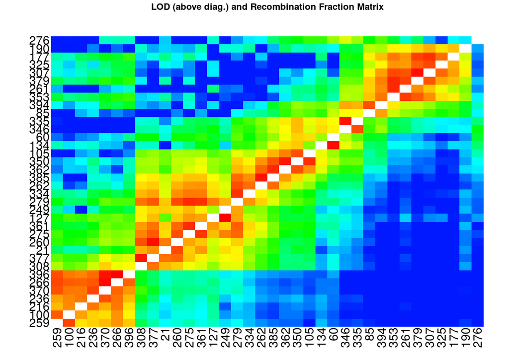

```r
rf.graph.table(LG14.fin, inter=FALSE)
```

```r
LG14.new <- drop.marker(LG14.fin, 276)
LG14.new <- map(LG14.new)

LG14.new.ord <- try.seq(LG14.new, 276, draw.try=FALSE)
LG14.test <- make.seq(LG14.new.ord, 1)

LG14.test.fin <- LG14.new
LG14.test.fin

rf.graph.table(LG14.test.fin)
```

Em primeiro passo, o marcador MgSTS38 foi retirado e testado suas posições com a função **try.seq()**. Como resultado, a melhor posição seria a mesma inicial (posição 36) e a segunda melhor seria a posição 1 (no início do grupo). Desta forma, o marcador MgSTS38 foi reposicionado na posição 1 pela função **make.seq()**. Pode-se verificar que esse reposicionamento infracionou o comprimento do grupo. Desta forma, decidiu-se remover este marcador do grupo de ligação 14.

Essa retirada possibilitou obter um grupo de ligação com maior verossimilhança e menor comprimento, comparado ao grupo incluindo todos os marcadores.

| Grupo 14 | Verossimilhança | Comprimento | N. Marcadores |
| --- | --- | --- | --- |
| Todos os marcadores | -4246.14 | 333.00 | 36 |
| Com MgSTS38 na 2ª melhor posição | -4247.767 | 441.18 | 36 |
| Sem MgSTS38 | -3982.24 | 268.41 | 35 |

É importante considerar que foram realizadas várias tentativas de remoção e inclusão de marcadores, até obter um grupo de ligação com melhor ordenação, avaliado pela verossimilhança e comprimento do grupo.

```r
ripple.seq(LG14.test.fin, ws=5, LOD=3)
```

A partir da função **ripple.seq()**, pode-se verificar uma mudança local na ordem de alguns marcadores do grupo de ligação 14. Comparando com o mapa de referência, essa mudança era concordante e portanto optou-se por conservar a ordem do mapa de referência, realizando a mudança sugerida pela função **ripple.seq()**.

```r
temp <- LG14.test.fin$seq.num
temp

temp[4:7] <- c(266, 396, 370, 236)
temp[14:15] <- c(249, 127)
temp[29:30] <- c(261, 353)
temp

LG14.new.fin <- make.seq(freqrecomb, temp)
LG14.new.fin <- map(LG14.new.fin)
LG14.new.fin
```

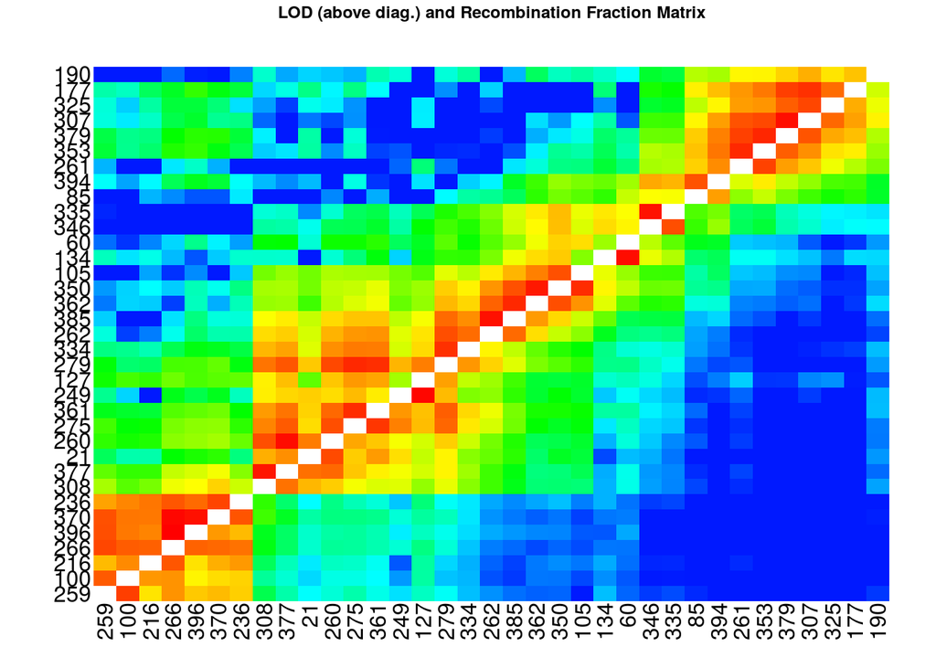

| Grupo 14 | Verossimilhança | Comprimento | N. Marcadores |
| --- | --- | --- | --- |
| Sem verificação ripple | -3982.24 | 268.41 | 35 |
| Com mudança de ordenamento | -3969.626 | 264.89 | 35 |

```r
rf.graph.table(LG14.new.fin, inter=FALSE)
```

**Grupo 2**

```r
LG2 <- make.seq(grupos, 2)   # trabalhando com o grupo de ligação 2
LG2
```

Neste grupo de ligação, foram agrupados 22 marcadores, sendo 12 marcadores coincidentes com os marcadores do LG2 do mapa de referência e 10 novos marcadores.

```r
LG2.rcd <- rcd(LG2)

rf.graph.table(LG2.rcd)
```

```r
LG2.ord <- order.seq(input.seq=LG2,
                        n.init = 5,
                        subset.search = "twopt",
                        twopt.alg = "rcd",
                        THRES = 3,
                        draw.try = FALSE,
                        wait = 1,
                        touchdown=TRUE)
LG2.ord

LG2.new.fin <- make.seq(LG2.ord, "force")
LG2.new.fin

round(diff(cumsum(LG2.new.fin$seq.rf)), 3)   # Calcula a frequência de recombinação
                                          # entre pares de marcadores
```

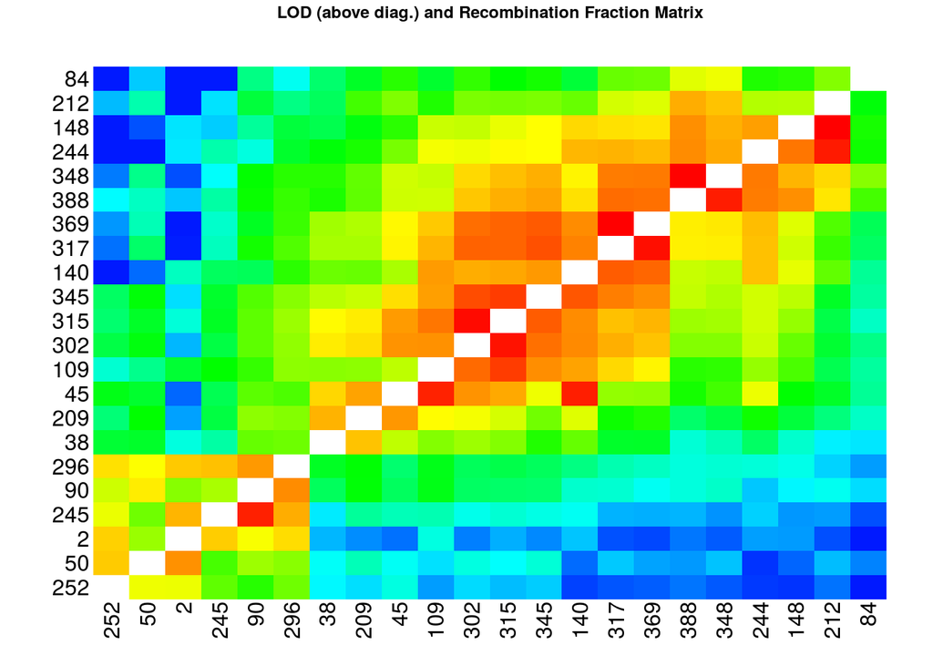

```r
rf.graph.table(LG2.new.fin, inter=FALSE)
```

Observando o gráfico do *heatmap*, evidenciou-se que o grupo apresentou uma boa ordenação. Esta evidência foi confirmada também na ordenação local, pela função **ripple.seq**.

```r
ripple.seq(LG2.new.fin, ws=5, LOD=3)
```

[output not shown]

**Segundo grupo maior**

```r
maior2 <- make.seq(grupos, 3) # trabalhando com o grupo de ligação 3
maior2
```

Neste grupo de ligação, foram agrupados 87 marcadores, sendo 12 marcadores coincidentes com os marcadores do LG3, 9 marcadores coincidentes com os do LG7 e 15 marcadores coincidentes com os do LG10 do mapa original. Posteriormente, os marcadores serão ordenados dentro deste grupo de ligação por um critério de ordenação previamente selecionado.

```r
maior2.rcd <- rcd(maior2)

rf.graph.table(maior2.rcd)
```

```r
maior2.ord <- order.seq(input.seq=maior2,
                        n.init = 5,
                        subset.search = "twopt",
                        twopt.alg = "rcd",
                        THRES = 3,
                        draw.try = FALSE,
                        wait = 1,
                        touchdown=TRUE)
maior2.ord

maior2.fin <- make.seq(maior2.ord, "force")
maior2.fin
```

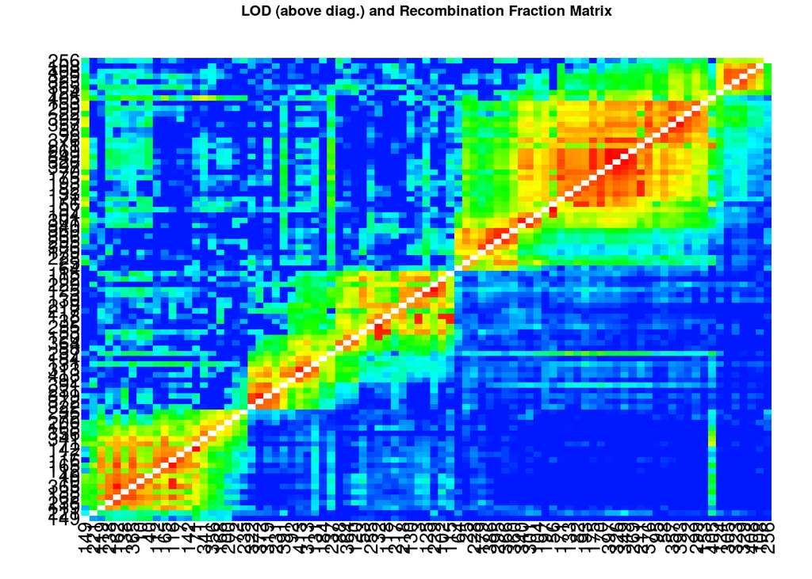

```r
rf.graph.table(maior2.fin, inter=FALSE)
```

Subdividindo o segundo maior grupo de ligação:

```r
maior2seq1 <- make.seq(freqrecomb, c(149, 221, 119, 238, 162, 138, 365, 10, 40, 112, 165,
                                  116, 7, 142, 71, 341, 356, 168, 200, 72, 235 ))
maior2seq2 <- make.seq(freqrecomb, c(322, 372, 319, 231, 391, 92, 413, 313, 131, 184, 237,
                                  88, 364, 120, 53, 255, 32, 118, 217, 218, 130, 3, 125,
                                  229, 102, 115))
maior2seq3 <- make.seq(freqrecomb, c(64, 25, 228, 179, 386, 295, 366, 360, 340, 301, 104, 197,
                                  56, 171, 133, 82, 193, 175, 70, 397, 326, 349, 269, 211,
                                  376, 95, 58, 357, 393, 22, 299, 153, 405, 124, 305, 323,
                                  329, 408, 108, 256))
```

**Grupo 3**

Agora trabalhando com a segunda sequência gerada, a qual corresponde ao LG3 do mapa de referência.

```r
LG3.ord <- order.seq(input.seq=maior2seq2,
                        n.init = 5,
                        subset.search = "twopt",
                        twopt.alg = "rcd",
                        THRES = 3,
                        draw.try = FALSE,
                        wait = 1,
                        touchdown=TRUE)
LG3.ord

LG3.fin <- make.seq(LG3.ord, "force")
LG3.fin
```

Neste grupo de ligação, foram agrupados 26 marcadores, sendo 12 marcadores coincidentes com os marcadores do LG3 do mapa de referência e 14 novos marcadores.

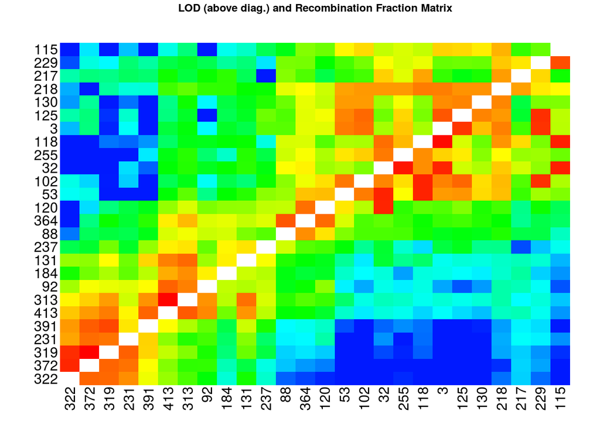

```r
rf.graph.table(LG3.fin, inter=FALSE)
```

```r
LG3.new <- drop.marker(LG3.fin, c(217, 115))
LG3.new <- map(LG3.new)

LG3.new.ord <- try.seq(LG3.new, 115, draw.try=FALSE)
LG3.test.fin <- make.seq(LG3.new.ord, 24)

rf.graph.table(LG3.test.fin)
```

Comparando o grupo de ligação final com o inicial.

| Grupo 3 | Verossimilhança | Comprimento | N. Marcadores |
| --- | --- | --- | --- |
| Todos os marcadores | -2781.075 | 198.94 | 26 |
| Reposicionando CB187 e eliminando BC70 | -2696.105 | 201.63 | 25 |

Foi eliminado o marcador BC70. Este marcador está presente no mapa de referência, no entanto com os novos marcadores, não foi possível encontrar uma posição ótima para este marcador.

```r
ripple.seq(LG3.test.fin, ws=5, LOD=3)
```

```r
temp <- LG3.test.fin$seq.num
temp

temp[6:10] <- c(92, 413, 313, 131, 184)
temp

LG3.new.fin <- make.seq(freqrecomb, temp)
LG3.new.fin <- map(LG3.new.fin)
LG3.new.fin
```

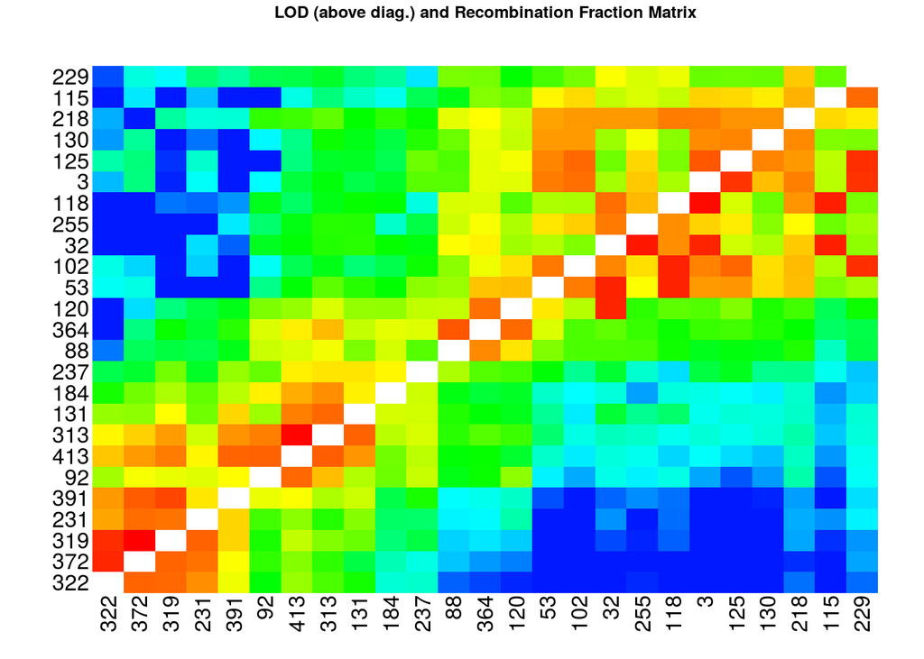

[output not shown]

```r
rf.graph.table(LG3.new.fin, inter=FALSE)
```

**Grupo 7**

Agora trabalhando com a primeira sequência gerada, a qual corresponde ao LG7 do mapa de referência.

```r
LG7.ord <- order.seq(input.seq=maior2seq1,
                        n.init = 5,
                        subset.search = "twopt",
                        twopt.alg = "rcd",
                        THRES = 3,
                        draw.try = FALSE,
                        wait = 1,
                        touchdown=TRUE)
LG7.ord

LG7.fin <- make.seq(LG7.ord, "force")
LG7.fin
```

Neste grupo de ligação, foram agrupados 21 marcadores, sendo 9 marcadores coincidentes com os marcadores do LG7 do mapa original e 12 novos marcadores.

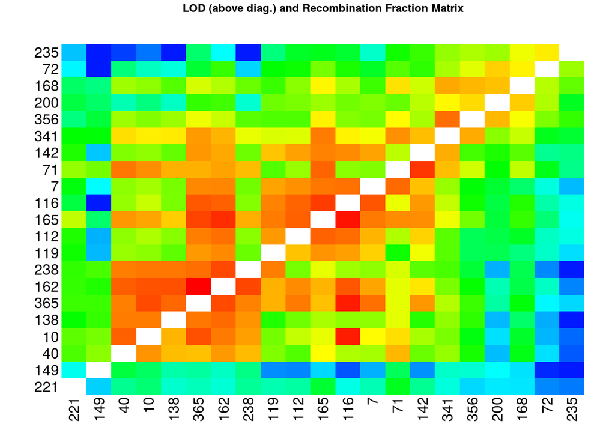

```r
rf.graph.table(LG7.fin, inter=FALSE)
```

Observando o *heatmap* inicial, houve problemas de ordenação dos marcadores. Desta forma, diversos testes foram feitos e optou-se por eliminar os marcadores BC128C e BD68.

```r
LG7.new <- drop.marker(LG7.fin, c(221, 149))
LG7.new <- map(LG7.new)

rf.graph.table(LG7.new)
```

Comparando o grupo de ligação final com o inicial.

| Grupo 7 | Verossimilhança | Comprimento | N. Marcadores |
| --- | --- | --- | --- |
| Todos os marcadores | -2238.607 | 227.72 | 21 |
| Eliminando BC128C e BD68 | -1856.256 | 137.49 | 19 |

Portanto, foram eliminados os marcadores BC128C e BD68. Diversos testes foram feitos tentando realocá-los em outras posições, verificando posições ótimas com a função **try.seq()**. No entanto, as melhores posições eram sempre nos extremos, causando grandes gaps no grupo de ligação. Por ese motivo se prefiriu deixá-los fora do grupo de ligação.

```r
ripple.seq(LG7.new, ws=5, LOD=3)
```

A partir da função **ripple.seq()**, pode-se verificar uma mudança local na ordem dos marcadores na posição 2 a 6 e na posição 12 e 13 do grupo de ligação 7. Comparando com o mapa de referência, essa mudança era concordante e portanto optou-se por conservar a ordem do mapa de referência, realizando a mudança sugerida pela função **ripple.seq()**.

```r
temp <- LG7.new$seq.num
temp

temp[2:6] <- c(138, 238, 162, 365, 10)
temp[12:13] <- c(142, 71)
temp

LG7.new.fin <- make.seq(freqrecomb, temp)
LG7.new.fin <- map(LG7.new.fin)
LG7.new.fin
```

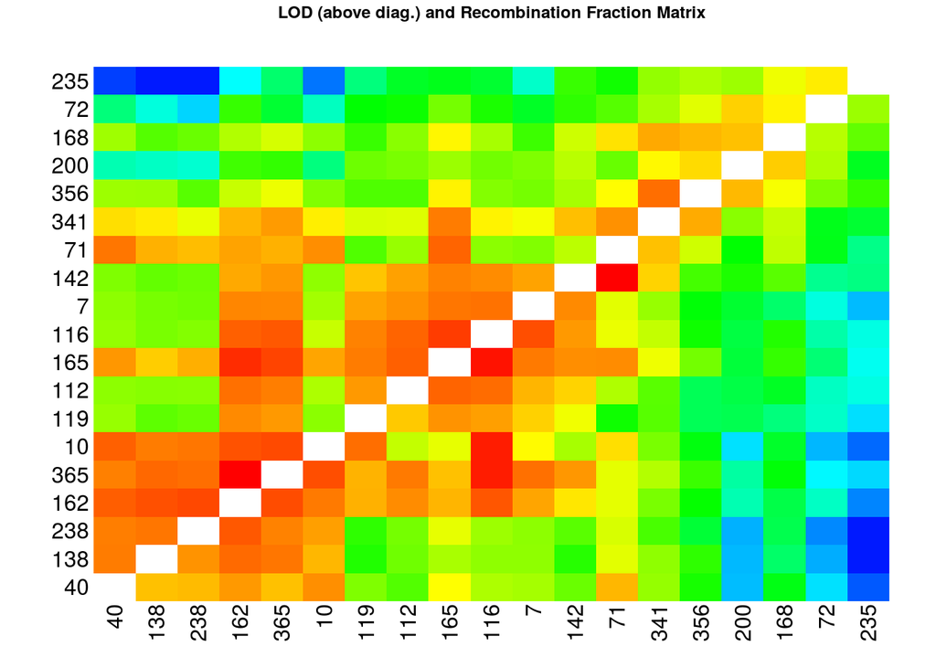

| Grupo 7 | Verossimilhança | Comprimento | N. Marcadores |
| --- | --- | --- | --- |
| Sem verificação ripple | -1856.256 | 137.49 | 19 |
| Com mudança de ordenamento | -1854.409 | 136.76 | 19 |

```r
rf.graph.table(LG7.new.fin, inter=FALSE)
```

Uma observação importante é que, mesmo eliminando dois marcadores, neste grupo de ligação ainda é duplicado o número de marcadores em comparação com o grupo de ligação do mapa de referência.

**Grupo 10**

Agora trabalhando com a terceira sequência gerada, a qual corresponde ao LG10 do mapa de referência.

```r
LG10.ord <- order.seq(input.seq=maior2seq3,
                        n.init = 5,
                        subset.search = "twopt",
                        twopt.alg = "rcd",
                        THRES = 3,
                        draw.try = FALSE,
                        wait = 1,
                        touchdown=TRUE)
LG10.ord

LG10.new <- make.seq(LG10.ord, "force")
LG10.new
```

Neste grupo de ligação, foram agrupados 40 marcadores, sendo 15 marcadores coincidentes com os marcadores do LG10 do mapa de referência e 25 novos marcadores.

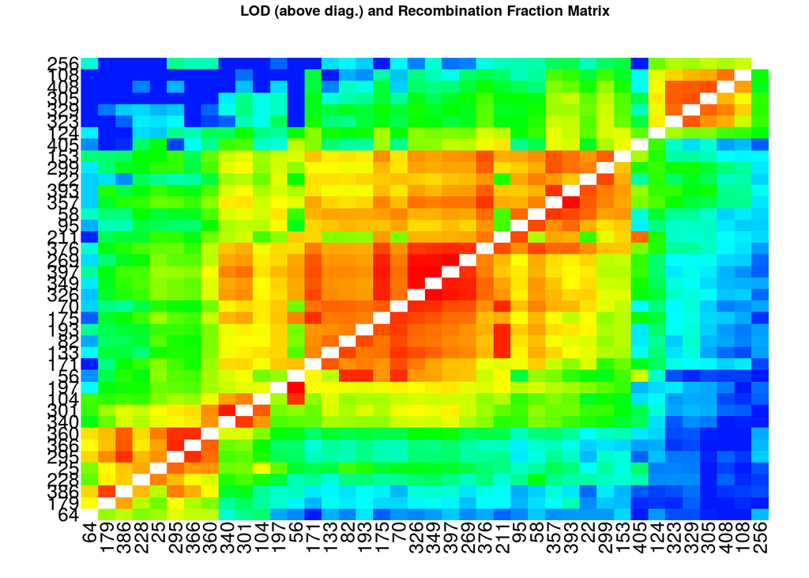

```r
rf.graph.table(LG10.new, inter=FALSE)
```

Observando o *heatmap* inicial, houve problemas de ordenação dos marcadores. Desta forma, diversos testes foram feitos.

```r
LG10.test <- drop.marker(LG10.new, c(211, 405))
LG10.test <- map(LG10.test)

LG10.new.ord <- try.seq(LG10.test, 211, draw.try=FALSE)
LG10.test <- make.seq(LG10.new.ord, 24)

rf.graph.table(LG10.test)
```

Comparando o grupo de ligação final com o inicial.

| Grupo 10 | Verossimilhança | Comprimento | N. Marcadores |
| --- | --- | --- | --- |
| Todos os marcadores | -3848.987 | 287.26 | 40 |
| Eliminando MgSTS441 e reordenando BC131 | -3735.533 | 271.84 | 39 |

Foi eliminado o marcador MgSTS441 e reordenado o marcador BC131. O marcador MgSTS441 além de não apresentar um bom ordenamento no grupo, continha 48% de dados perdidos, o que estaria viesando as estimativas de recombinação desse marcador. Logo, preferiu-se não manter este marcador no grupo.

```r
ripple.seq(LG10.test, ws=5, LOD=3)
```

A partir da função **ripple.seq()**, pode-se verificar que a alteração na posição do marcador BC131 não foi consistente, de forma que o mais indicado seria mantê-lo na posição inicial. Assim, optou-se por apenas eliminar o marcador MgSTS441.

```r
LG10.new.fin <- drop.marker(LG10.new, 405)
LG10.new.fin <- map(LG10.new.fin)
LG10.new.fin
```

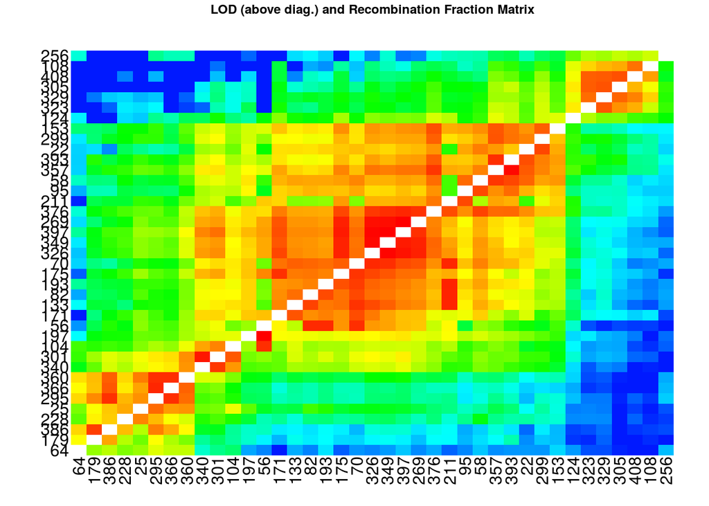

| Grupo 10 | Verossimilhança | Comprimento | N. Marcadores |
| --- | --- | --- | --- |
| Eliminando MgSTS441 | -3725.838 | 270.29 | 39 |

```r
rf.graph.table(LG10.new.fin, inter=FALSE)
```

Os marcadores CB309 e AAT283 ficaram em ordem inversa à ordem obtida no mapa de referência. Foram feitos testes para verificar a melhor ordem e igualando à ordem do mapa de referência, o grupo de ligação gerado foi de maior comprimento e com menor verossimilhança. Logo, optou-se por manter a nova ordem estabelecida com os novos marcadores.

**Grupo 4**

```r
LG4 <- make.seq(grupos, 4)  # trabalhando com o grupo de ligação 4
LG4
```

Neste grupo de ligação, foram agrupados 40 marcadores, sendo 17 marcadores coincidentes com os marcadores do LG4 do mapa de referência e 23 novos marcadores.

```r
LG4.rcd <- rcd(LG4)

rf.graph.table(LG4.rcd)
```

```r
LG4.ord <- order.seq(input.seq=LG4,
                        n.init = 5,
                        subset.search = "twopt",
                        twopt.alg = "rcd",
                        THRES = 3,
                        draw.try = FALSE,
                        wait = 1,
                        touchdown=TRUE)
LG4.ord

LG4.fin <- make.seq(LG4.ord, "force")
LG4.fin
```

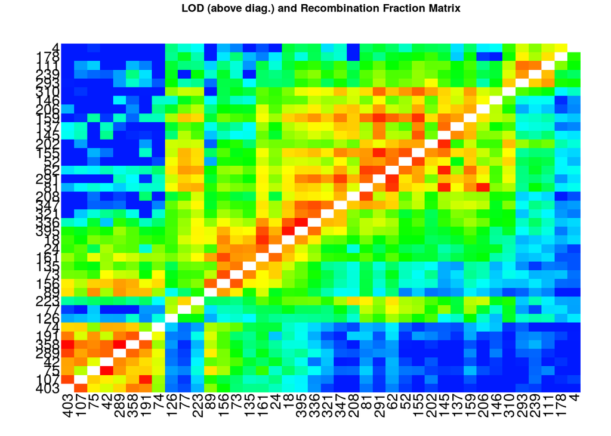

```r
rf.graph.table(LG4.fin, inter=FALSE)
```

```r
LG4.test <- drop.marker(LG4.fin, c(223, 77, 126))
LG4.test <- map(LG4.test)

LG4.new.ord <- try.seq(LG4.test, 223, draw.try=FALSE)
LG4.new.test <- make.seq(LG4.new.ord, 31)
LG4.test2 <- map(LG4.new.test)

LG4.new.ord2 <- try.seq(LG4.test2, 77, draw.try=FALSE)
LG4.new.test2 <- make.seq(LG4.new.ord2, 32)

rf.graph.table(LG4.new.test2)
```

Avaliando o *heatmap* para o grupo de ligação 4, foi retirado do mapa o marcador BD411 e reordenado os marcadores CC531 e CA384. Essas mudanças possibilitou obter um grupo de ligação com maior verossimilhança e menor comprimento, comparado ao grupo incluindo todos os marcadores.

| Grupo 4 | Verossimilhança | Comprimento | N. Marcadores |
| --- | --- | --- | --- |
| Todos os marcadores | -4762.859 | 463.81 | 40 |
| Menos BD411 e reposicionando os outros | -4559.079 | 381.48 | 39 |

```r
ripple.seq(LG4.new.test2, ws=5, LOD=3)
```

A partir da função **ripple.seq()**, pode-se verificar uma mudança local na ordem dos marcadores na posição 22 e 23 e na posição 30 a 33 do grupo de ligação 4.

```r
temp <- LG4.new.test2$seq.num
temp

temp[22:23] <- c(62, 291)
temp[30:33] <- c(146, 206, 223, 77)
temp

LG4.new.fin <- make.seq(freqrecomb, temp)
LG4.new.fin <- map(LG4.new.fin)
LG4.new.fin
```

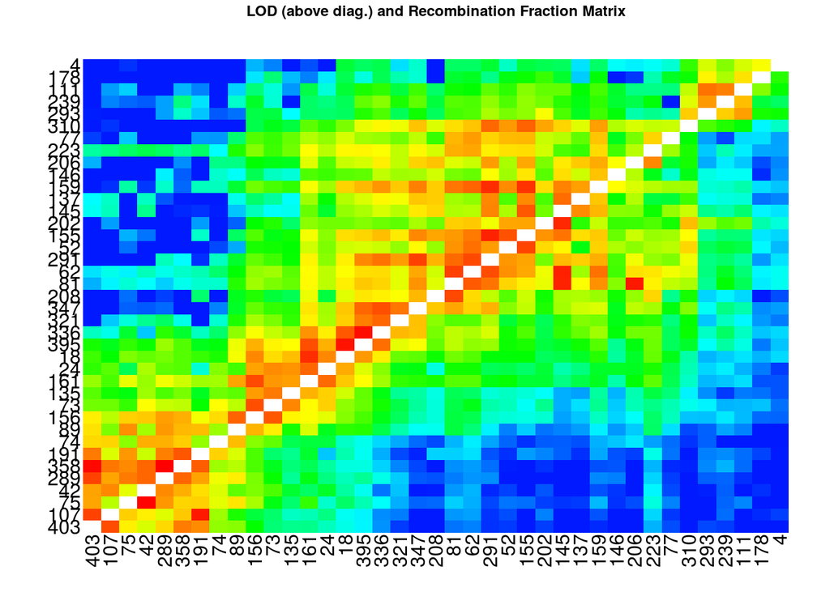

| Grupo 4 | Verossimilhança | Comprimento | N. Marcadores |
| --- | --- | --- | --- |
| Sem verificação ripple | -4559.079 | 381.48 | 39 |
| Com mudança de ordenamento | -4546.883 | 363.16 | 39 |

```r
rf.graph.table(LG4.new.fin, inter=FALSE)
```

**Grupo 5**

```r
LG5 <- make.seq(grupos, 5)    # trabalhando com o grupo de ligação 5
LG5
```

Neste grupo de ligação, foram agrupados 21 marcadores, sendo 12 marcadores coincidentes com os marcadores do LG5 do mapa de referência e 9 novos marcadores.

```r
LG5.rcd <- rcd(LG5)

rf.graph.table(LG5.rcd)
```

```r
LG5.ord <- order.seq(input.seq=LG5,
                        n.init = 5,
                        subset.search = "twopt",
                        twopt.alg = "rcd",
                        THRES = 3,
                        draw.try = FALSE,
                        wait = 1,
                        touchdown=TRUE)
LG5.ord

LG5.new.fin <- make.seq(LG5.ord, "force")
LG5.new.fin
```

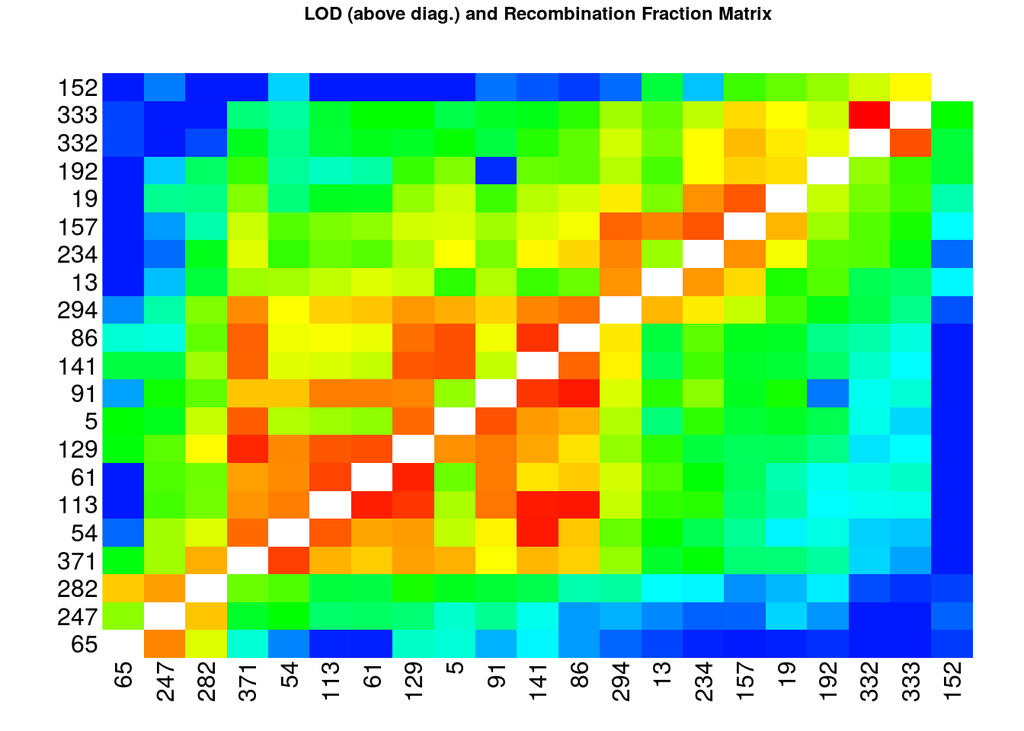

```r
rf.graph.table(LG5.new.fin, inter=FALSE)
```

```r
ripple.seq(LG5.new.fin, ws=5, LOD=3)
```

A função **ripple.seq()** verificou o ordenamento ao nível local e foi consistente com o ordenamento global. Desta forma, não foi realizada mudanças neste grupo de ligação.

| Grupo 5 | Verossimilhança | Comprimento | N. Marcadores |
| --- | --- | --- | --- |
| Todos os marcadores | -2417.265 | 182.24 | 21 |

**Grupo 6**

```r
LG6 <- make.seq(grupos, 6)   # trabalhando com o grupo de ligação 6
LG6
```

Neste grupo de ligação, foram agrupados 51 marcadores, sendo 12 marcadores coincidentes com os marcadores do LG6 do mapa de referência e 39 novos marcadores.

```r
LG6.rcd <- rcd(LG6)

rf.graph.table(LG6.rcd)
```

```r
LG6.ord <- order.seq(input.seq=LG6,
                        n.init = 5,
                        subset.search = "twopt",
                        twopt.alg = "rcd",
                        THRES = 3,
                        draw.try = FALSE,
                        wait = 1,
                        touchdown=TRUE)
LG6.ord

LG6.fin <- make.seq(LG6.ord, "force")
LG6.fin
```

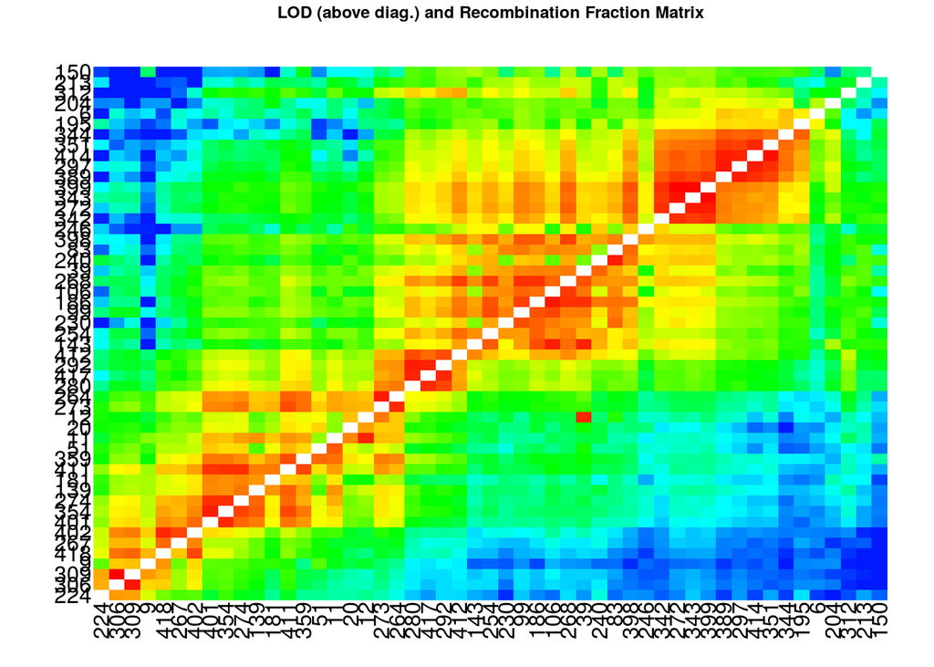

```r
rf.graph.table(LG6.fin, inter=FALSE)
```

A partir do gráfico *heatmap* pode-se verificar uma combinação de marcadores (AA270 e BA222) que aparecem como um ponto forte longe da diagonal do gráfico. Quando examinado essa combinação, observou-se que ambos são dominantes e segregando para alelos diferentes (AA270: A- : AA e BA222: B- : BB) e portanto a frequência de recombinação calculada não pode ser considerada confiável.

```r
LG6.new <- drop.marker(LG6.fin, c(143, 312, 150, 213, 204))
LG6.new <- map(LG6.new)

LG6.new.ord <- try.seq(LG6.new, 143,  draw.try=FALSE)

LG6.new.test <- make.seq(LG6.new.ord, 32)
rf.graph.table(LG6.new.test)
```

Avaliando o *heatmap* para o grupo de ligação 6, foi retirado do mapa os marcadores BD169, MgSTS480, BD55, BC125 e BC243. Em seguida, o marcador BD169 retornou ao grupo pela função **try.seq()**, sendo inserido na posição 32. Os demais marcadores (MgSTS480, BD55, BC125 e BC243) foram retirados do grupo pois estavam inflacionando seu comprimento, tendo grandes gaps entre eles. Essas retiradas e reordenamento do marcador BD169 possibilitaram obter um grupo de ligação com maior verossimilhança e menor comprimento, comparado ao grupo incluindo todos os marcadores.

| Grupo 6 | Verossimilhança | Comprimento | N. Marcadores |
| --- | --- | --- | --- |
| Todos os marcadores | -4881.188 | 387.68 | 51 |
| Menos MgSTS480, BD55, BC125 e BC243 e reordenado o BD169 | -4268.619 | 248.81 | 47 |

```r
ripple.seq(LG6.new.test, ws=5, LOD=3)
```

```r
temp <- LG6.new.test$seq.num
temp

temp[26:36] <- c(268, 106, 186, 99, 230, 143, 39, 83, 240, 246, 398)
temp

LG6.new.fin <- make.seq(freqrecomb, temp)
LG6.new.fin <- map(LG6.new.fin)
LG6.new.fin
```

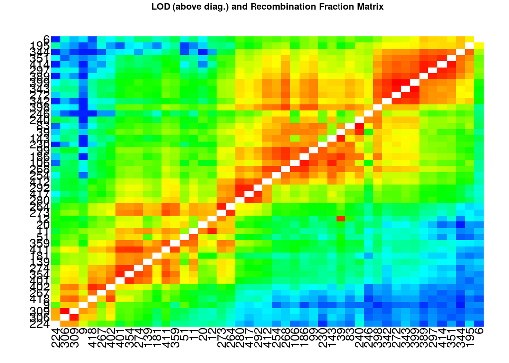

| Grupo 6 | Verossimilhança | Comprimento | N. Marcadores |
| --- | --- | --- | --- |
| Sem verificação ripple | -4268.619 | 248.81 | 47 |
| Com mudança de ordenamento | -4263.356 | 246.10 | 47 |

```r
rf.graph.table(LG6.new.fin, inter=FALSE)
```

O novo ordenamento do grupo apresentou maior verossimilhança e menor comprimento, mesmo que esta diferença tenha sido pouca.

**Grupo 8**

```r
LG8 <- make.seq(grupos, 7)
LG8
```

Neste grupo de ligação, foram agrupados 32 marcadores, sendo 15 marcadores coincidentes com os marcadores do LG8 do mapa de referência e 17 novos marcadores. Vale resaltar que o marcador CYCLB do mapa original recebeu o nome de CYCB neste novo mapa.

```r
LG8.rcd <- rcd(LG8)

rf.graph.table(LG8.rcd)
```

```r
LG8.ord <- order.seq(input.seq=LG8,
                        n.init = 5,
                        subset.search = "twopt",
                        twopt.alg = "rcd",
                        THRES = 3,
                        draw.try = FALSE,
                        wait = 1,
                        touchdown=TRUE)
LG8.ord

LG8.new.test <- make.seq(LG8.ord, "force")
LG8.new.test
```

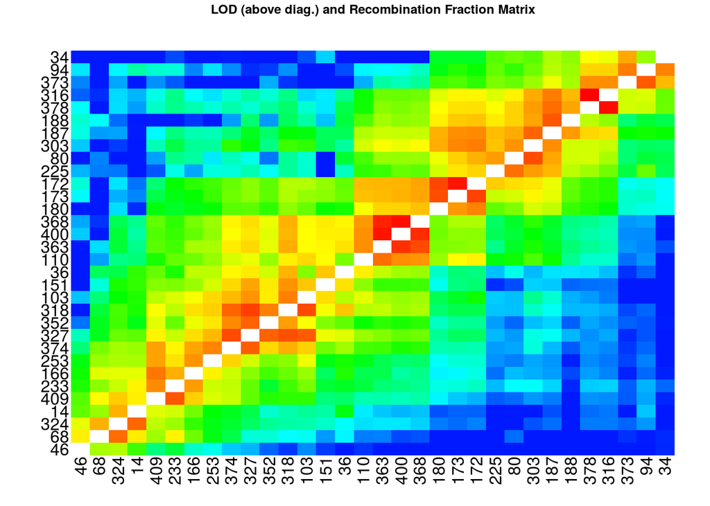

```r
rf.graph.table(LG8.new.test, inter=FALSE)
```

```r
ripple.seq(LG8.new.test, ws=5, LOD=3)
```

A partir da função **ripple.seq()**, pode-se verificar uma mudança local na ordem dos marcadores na posição 14 e 15 do grupo de ligação 8.

```r
temp <- LG8.new.test$seq.num
temp

temp[14:15] <- c(36, 151)
temp

LG8.new.fin <- make.seq(freqrecomb, temp)
LG8.new.fin <- map(LG8.new.fin)
LG8.new.fin
```

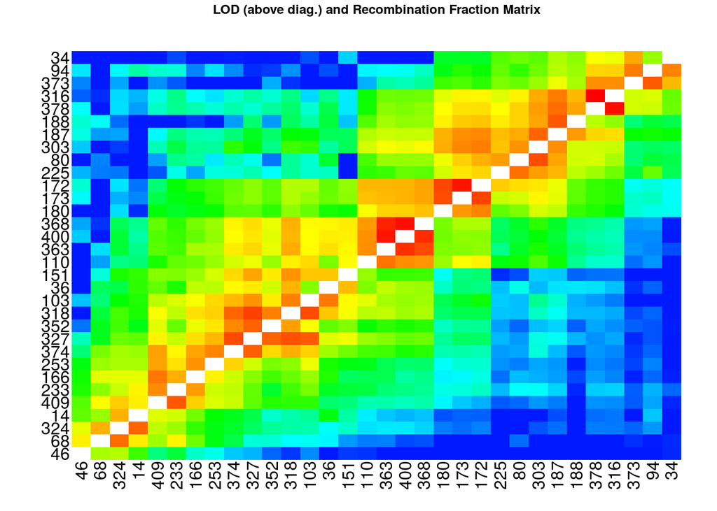

| Grupo 8 | Verossimilhança | Comprimento | N. Marcadores |
| --- | --- | --- | --- |
| Sem verificação ripple | -3769.319 | 258.17 | 32 |
| Com mudança de ordenamento | -3766.681 | 257.85 | 32 |

```r
rf.graph.table(LG8.new.fin, inter=FALSE)
```

O novo ordenamento do grupo apresentou maior verossimilhança e menor comprimento, mesmo que esta diferença tenha sido pouca.

**Grupo 9**

```r
LG9 <- make.seq(grupos, 8)
LG9
```

Neste grupo de ligação, foram agrupados 26 marcadores, sendo 13 marcadores coincidentes com os marcadores do LG9 do mapa de referência e 13 novos marcadores.

```r
LG9.rcd <- rcd(LG9)

rf.graph.table(LG9.rcd)
```

```r
LG9.ord <- order.seq(input.seq=LG9,
                        n.init = 5,
                        subset.search = "twopt",
                        twopt.alg = "rcd",
                        THRES = 3,
                        draw.try = FALSE,
                        wait = 1,
                        touchdown=TRUE)
LG9.ord

LG9.fin <- make.seq(LG9.ord, "force")
LG9.fin
```

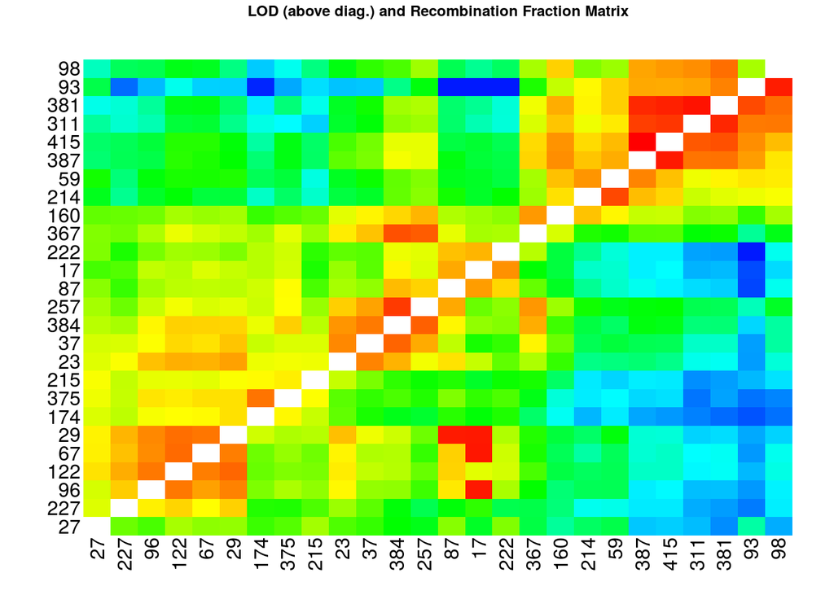

```r
rf.graph.table(LG9.fin, inter=FALSE)
```

Pode-se verificar alguns pontos fortes longe da diagonal do gráfico *heatmap*. Estes pontos se deve à ligação entre marcadores dominantes segregando para diferentes alelos. Como discutido anteriormente, a fração de recombinação estimada entre eles não pode ser dita como confiável. Testes de realocação dos marcadores envolvidos foram realizados, sendo o marcador AA167 eliminado.

```r
LG9.test <- drop.marker(LG9.fin, 17)
LG9.new.fin <- map(LG9.test)
LG9.new.fin
```

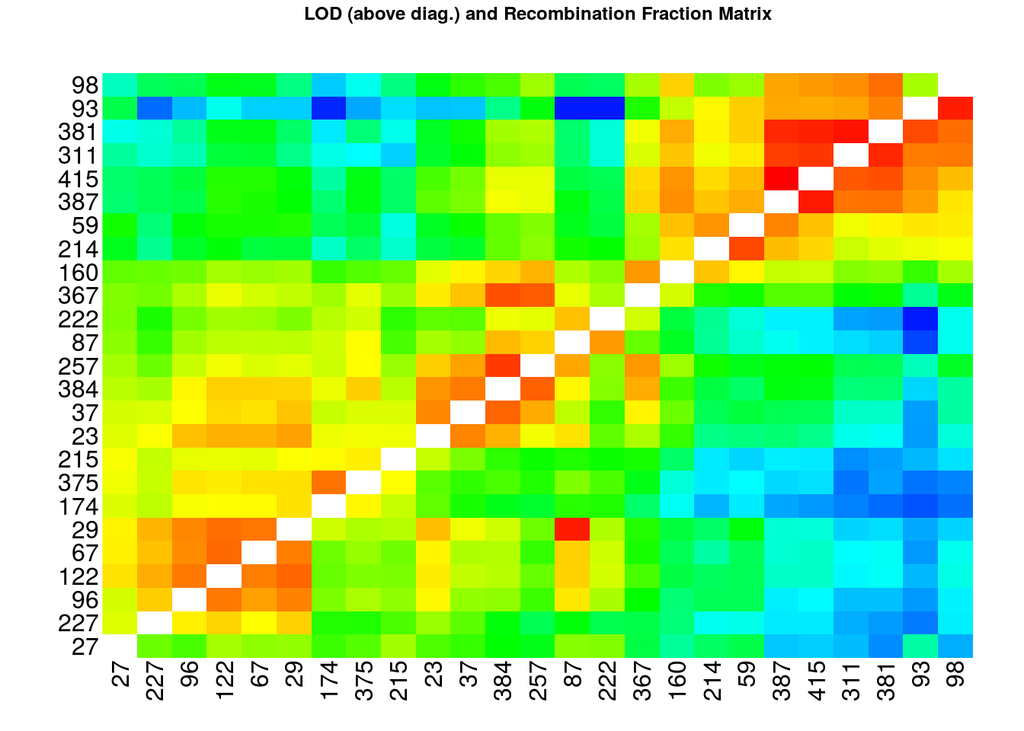

```r
rf.graph.table(LG9.new.fin, inter=FALSE)
```

O marcador AA167 foi eliminado porque este causava problema na ordenação dos marcadores sempre que colocado em uma nova posição.

| Grupo 9 | Verossimilhança | Comprimento | N. Marcadores |
| --- | --- | --- | --- |
| Todos os marcadores | -2760.116 | 217.19 | 26 |
| Menos AA167 | -2672.209 | 208.13 | 25 |

Pode-se observar que a eliminação do marcador AA167 ocasionou uma melhor disposição dos marcadores no grupo de ligação.

```r
ripple.seq(LG9.new.fin, ws=5, LOD=3)
```

A partir da função **ripple.seq()**, pode-se verificar uma mudança local na ordem dos marcadores na posição 14 a 16 do grupo de ligação 9. No entanto, quando implementada a mudança, a verossimilhança do grupo continuou a mesma e o comprimento do grupo aumentava em 10 cM. Portanto, optou-se por deixar o ordenamento original.

**Grupo 12**

```r
LG12 <- make.seq(grupos, 9)
LG12
```

Neste grupo de ligação, foram agrupados 29 marcadores, sendo 13 marcadores coincidentes com os marcadores do LG12 do mapa de referência e 16 novos marcadores.

```r
LG12.rcd <- rcd(LG12)

rf.graph.table(LG12.rcd)
```

```r
LG12.ord <- order.seq(input.seq=LG12,
                        n.init = 5,
                        subset.search = "twopt",
                        twopt.alg = "rcd",
                        THRES = 3,
                        draw.try = FALSE,
                        wait = 1,
                        touchdown=TRUE)
LG12.ord

LG12.fin <- make.seq(LG12.ord, "force")
LG12.fin
```

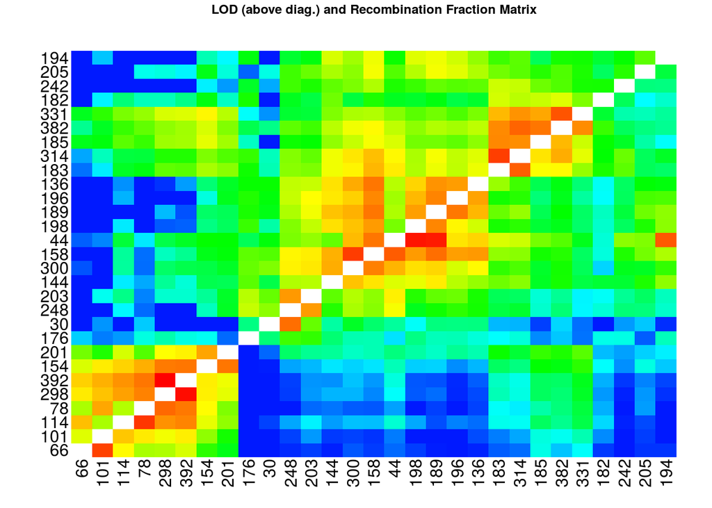

```r
rf.graph.table(LG12.fin, inter=FALSE)
```

Considerando a primeira ordem, sem trabalhar nos dados, o grupo de ligação ficaria como representado abaixo:

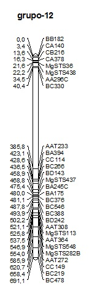

Pode-se verificar a presença de um grande gap (de 345.38 cM) entre os marcadores BC330 e AAT233. Assim, podemos visualizar a importância que é trabalhar bem os dados, retirando possíveis falso-positivos e reordenando marcadores nas melhores posições possíveis.

```r
LG12.test <- drop.marker(LG12, 194)

LG12.test.ord <- order.seq(input.seq=LG12.test,
                        n.init = 5,
                        subset.search = "twopt",
                        twopt.alg = "rcd",
                        THRES = 3,
                        draw.try = FALSE,
                        wait = 1,
                        touchdown=TRUE)

LG12.test.fin <- make.seq(LG12.test.ord, "force")
LG12.test.fin
```

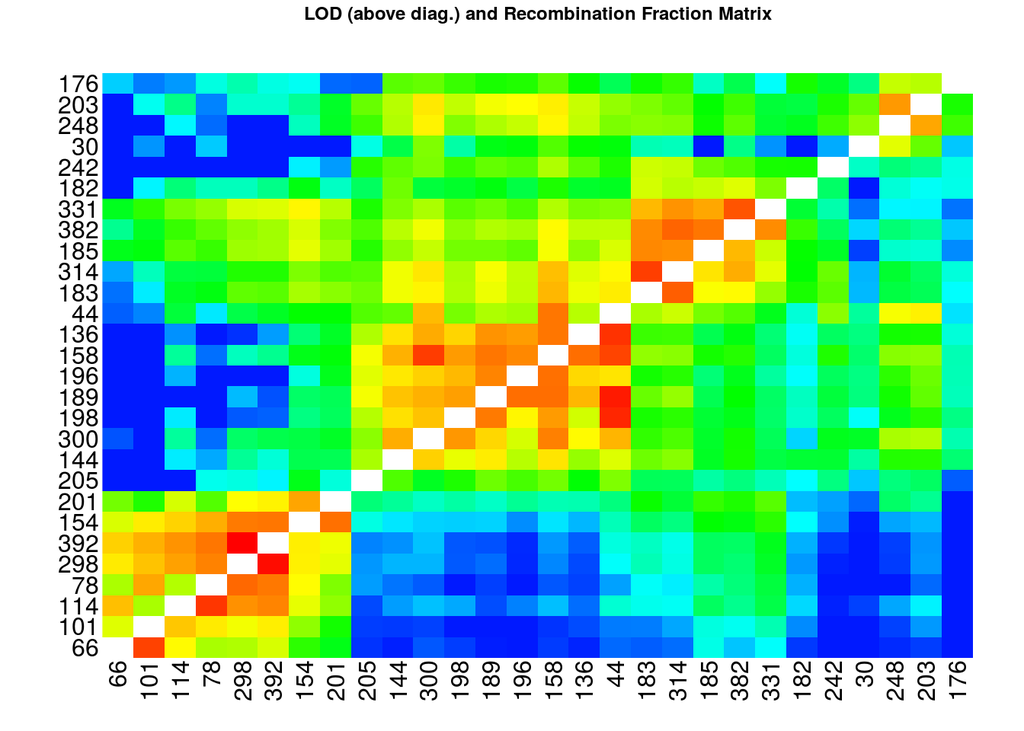

```r
rf.graph.table(LG12.test.fin, inter=FALSE)
```

Avaliando o *heatmap* para o grupo de ligação 12, foi retirado do mapa o marcador BC478. Este marcador foi facilmente verificado como falso-positivo, observando o *heatmap*. Essa retirada possibilitou obter um grupo de ligação com maior verossimilhança e menor comprimento, comparado ao grupo incluindo todos os marcadores.

| Grupo 12 | Verossimilhança | Comprimento | N. Marcadores |
| --- | --- | --- | --- |
| Todos os marcadores | -3524.141 | 691.09 | 29 |
| Menos BC478 | -3438.681 | 357.89 | 28 |

```r
ripple.seq(LG12.test.fin, ws=5, LOD=3)
```

A partir da função **ripple.seq()**, pode-se verificar uma mudança local na ordem de diversos marcadores do grupo de ligação 12.

```r
temp <- LG12.test.fin$seq.num
temp

temp[16:17] <- c(44, 136)
temp[20:22] <- c(382, 331, 185)
temp[25:28] <- c(176, 203, 248, 30)
temp

LG12.new.fin <- make.seq(freqrecomb, temp)
LG12.new.fin <- map(LG12.new.fin)
LG12.new.fin
```

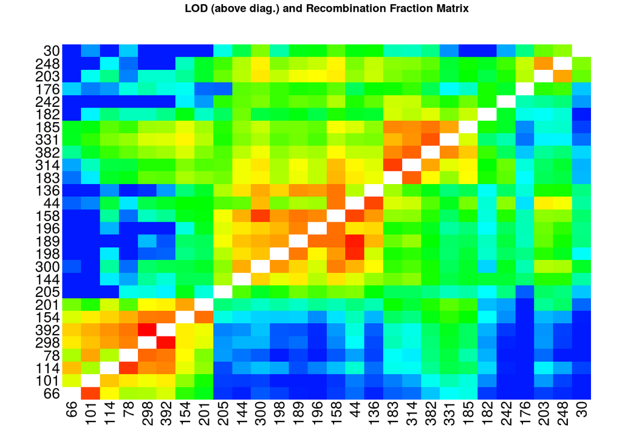

[output not shown]

```r
rf.graph.table(LG12.new.fin, inter=FALSE)
```

**Grupo 13**

```r
LG13 <- make.seq(grupos, 10)
LG13
```

Neste grupo de ligação, foram agrupados 21 marcadores, sendo 9 marcadores coincidentes com os marcadores do LG13 do mapa de referência e 12 novos marcadores.

```r
LG13.rcd <- rcd(LG13)

rf.graph.table(LG13.rcd)
```

```r
LG13.ord <- order.seq(input.seq=LG13,
                        n.init = 5,
                        subset.search = "twopt",
                        twopt.alg = "rcd",
                        THRES = 3,
                        draw.try = FALSE,
                        wait = 1,
                        touchdown=TRUE)
LG13.ord

LG13.new.fin <- make.seq(LG13.ord, "force")
LG13.new.fin
```

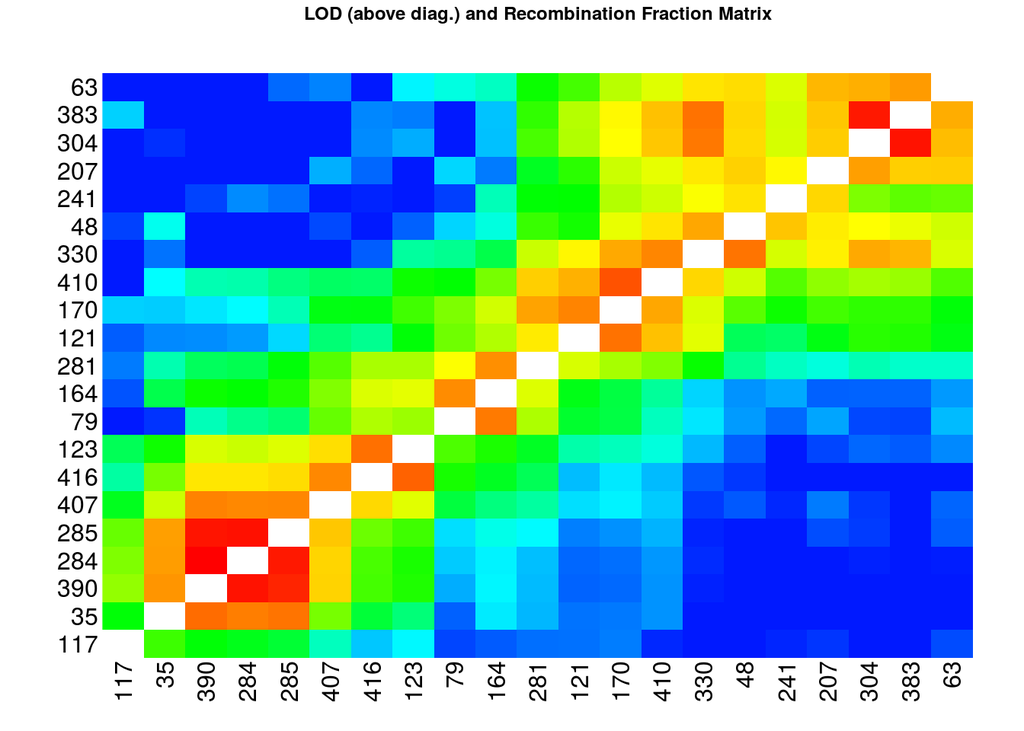

```r
rf.graph.table(LG13.new.fin, inter=FALSE)
```

```r
ripple.seq(LG13.new.fin, ws=5, LOD=3)
```

Neste grupo, não foi necessário o reordenamento dos marcadores. Mesmo com a função **ripple.seq()**, a ordenação foi consistente com a inicial.

| Grupo 13 | Verossimilhança | Comprimento | N. Marcadores |
| --- | --- | --- | --- |
| Todos os marcadores | -2461.734 | 188.77 | 21 |

### 6º passo

Visualização do mapa genético de *Mimulus*.

```r
mapa <- list(LG1.new.fin, LG2.new.fin, LG3.new.fin, LG4.new.fin, LG5.new.fin, LG6.new.fin, LG7.new.fin,
             LG8.new.fin, LG9.new.fin, LG10.new.fin, LG11.new.fin, LG12.new.fin, LG13.new.fin, LG14.new.fin)
```

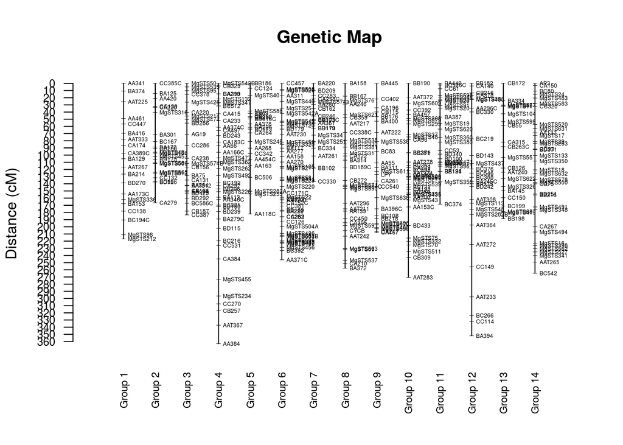

```r
draw.map(mapa, horizontal=FALSE, names = TRUE, grid = FALSE, cex.mrk=0.5, cex.grp=0.7)
```

```r
save.image("lista6.Rdata")

load("lista6.Rdata")
```

### Referências Bibliográficas

FISHMAN, L.; KELLY, A. J.; MORGAN, E.; WILLIS, J. H. A Genetic Map in the *Mimulus guttatus* Species Complex Reveals Transmission Ratio Distortion due to Heterospecific Interactions. **Genetics**, v. 159, p. 1701-1716, 2001.

XU, S. QTL mapping can benefit from segregation distortion. **Genetics**, v. 180, p. 2201-2208, 2008.